# Lecture 4 - A problem in theory?

# Context

## Unreliable methods, but what about theory?

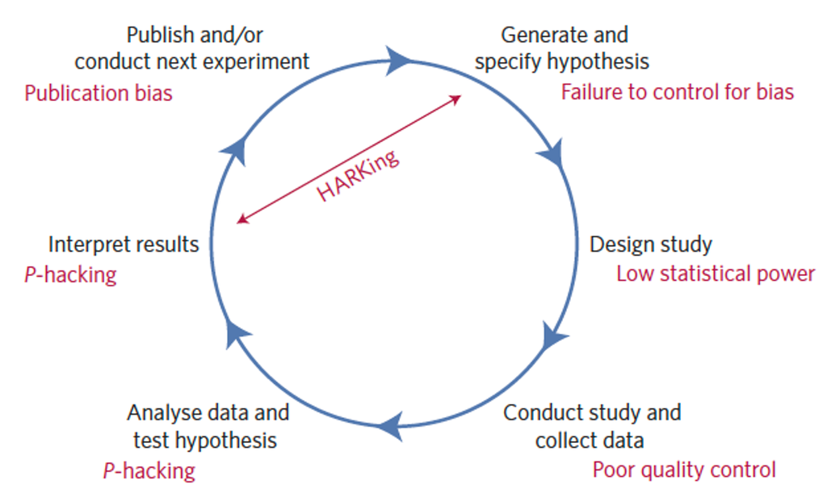

[figure not shown]

(Munafò et al., 2017)

## A problem in theory

Without a sufficiently well-developed theory, then it is hard to interpret results in a meaningful way.

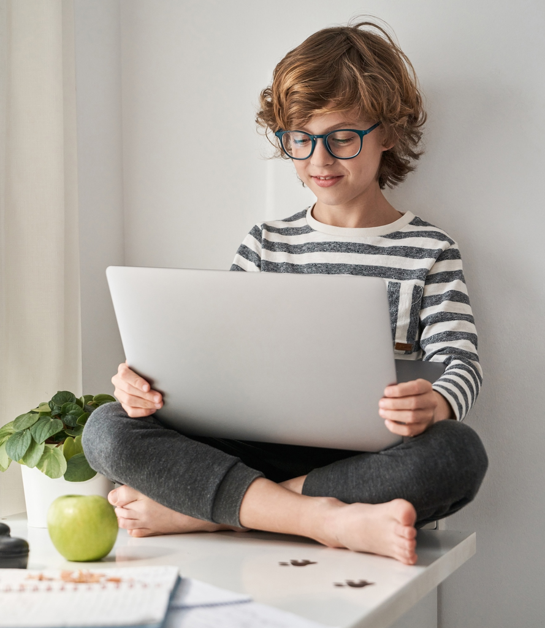

- Anything that turns up as statistically significant can be used to tell a story or sell newspapers.
- At most, only 0.4% of adolescent wellbeing is related to screen use - which only slightly surpasses the negative effect of regularly eating potatoes.

(Orben & Przybylski, 2019)

## A problem in theory

Predictions are often impossible to falsify because of infinite wriggle room…

[figure not shown]

Data

[figure not shown]

HARKing

[figure not shown]

Wriggle room

## Theory as a blueprint for science

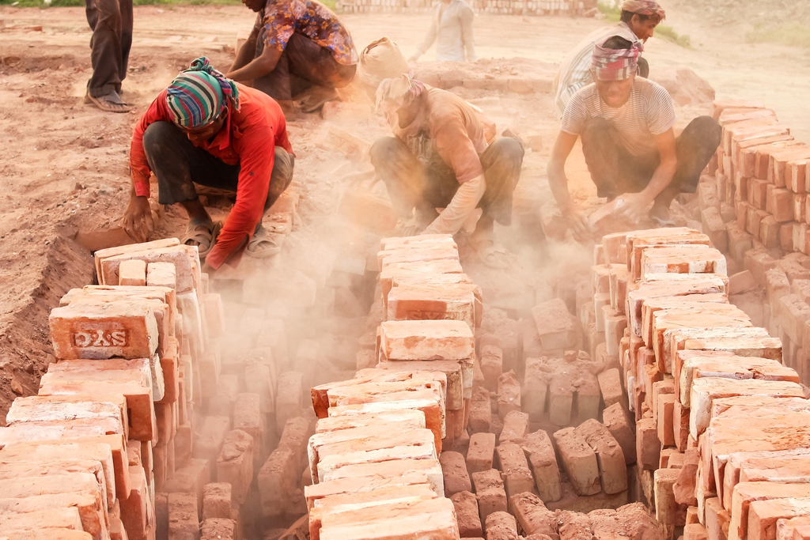

Evidence / Facts / Experiments

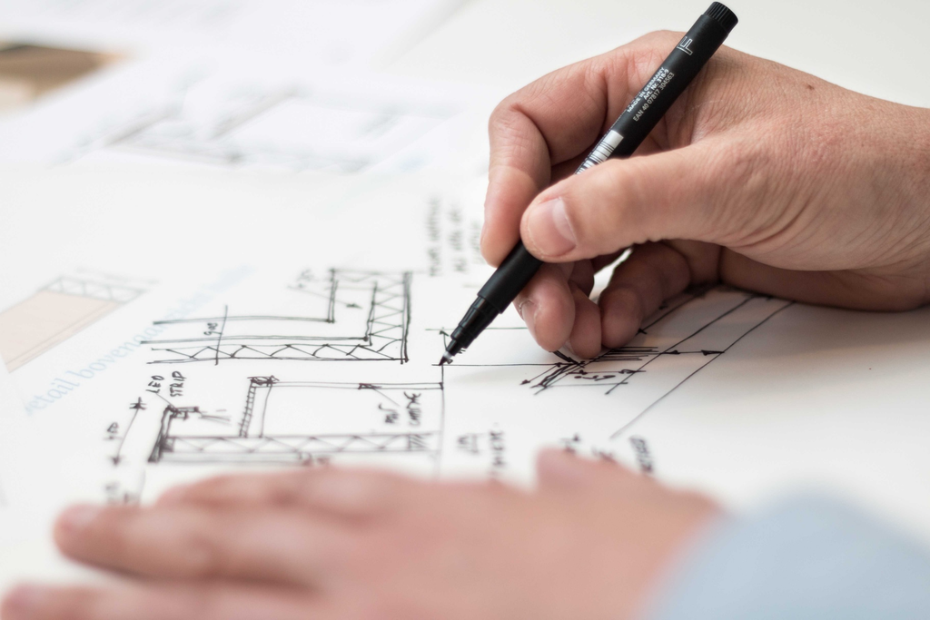

Theory

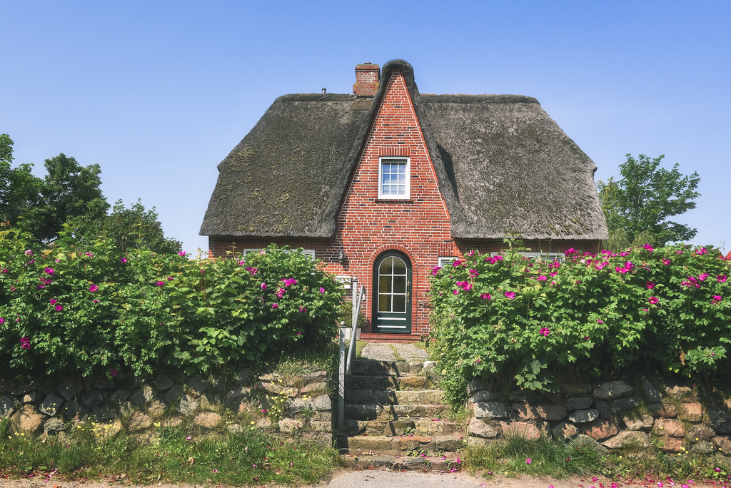

Oragnised knowledge

(Gray, 2017)

## Theory before the test

### Are psychological scientists ready to test hypotheses?

Inputs to informative hypothesis tests:

- Concept formation
- Developing measures
- Establishing relationships between concepts
- Boundary conditions and auxiliary assumptions
- Deriving statistical predictions

(Scheel et al., 2021)

## Concept formation

What do we mean by terms such as screen time, intrinsic motivation or depression?

[figure not shown]

**Why is this important?**

- Lots of time and money is spent having pointless debate and argument about reproducibility, when key terms are not adequately defined

## Measurement

**Measurement schmeasurement**

> We demonstrate that psychology is plagued by a measurement schmeasurement attitude: questionable measurement practices are common, hide a stunning source of researcher degrees of freedom, pose a serious threat to cumulative psychological science, but are largely ignored.

(Flake & Fried, 2020)

## Measurement

[figure not shown]

- Are the measures valid and reliable?
- And are they measuring the concept of interest?

(Flake & Fried, 2020)

## RMET - Example

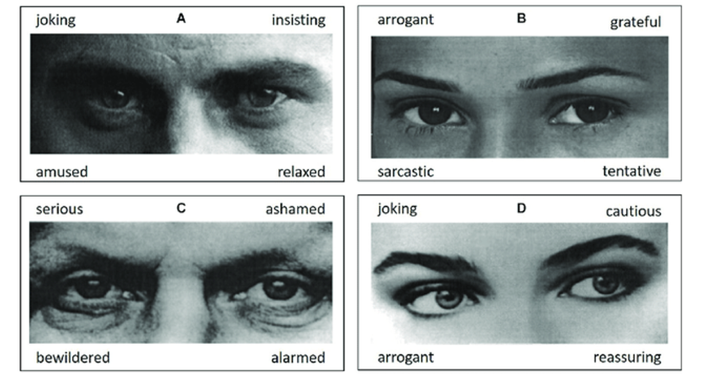

(Baron-Cohen et al., 2001)

## RMET - Problems

- The task is widely used in clinical and non-clinical settings, despite very limited evidence about the validity of the tool.
- A large-scale study has shown that it has poor psychometric properties, which provide considerable doubts to reliability and validity of the RMET as a measure of theory-of-mind.

(Higgins et al., 2022)

## Relationships between concepts

Once concepts are defined, we need a causal model of how they relate to each other.

[figure not shown]

## Boundary conditions

A good theory is clear about its boundary conditions – where does the theory apply and where is beyond its scope?

[figure not shown]

Basic vision vs. social cognition

[figure not shown]

Individual differences

[figure not shown]

Cultural variation

## Why is there a lack of good quality theory?

- OK, these seem like sensible ideas. But they are not **new** ideas?
- Paul Meehl was writing about this in (1967).

Question for the class:

- Why don’t researchers do more “theory” before the test?

# How can we improve theory building?

## How can we improve theory building?

- This is hard and it is generally undervalued

I’ll provide two examples:

- Theory Mapping
- Formal theory

## Theory mapping

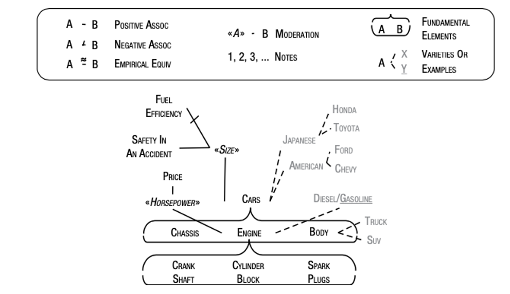

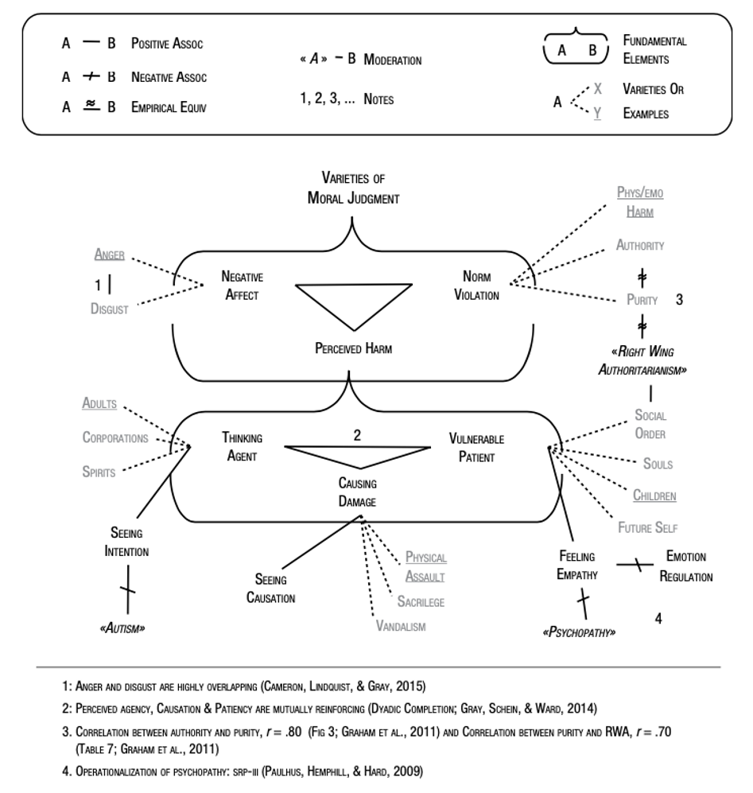

(Gray, 2017)

## Formal theory

- Psychological theory tends to be narrative
- Predictions are ordinal
- Formal theory is a mathematical description that can give rise to quantitative predictions

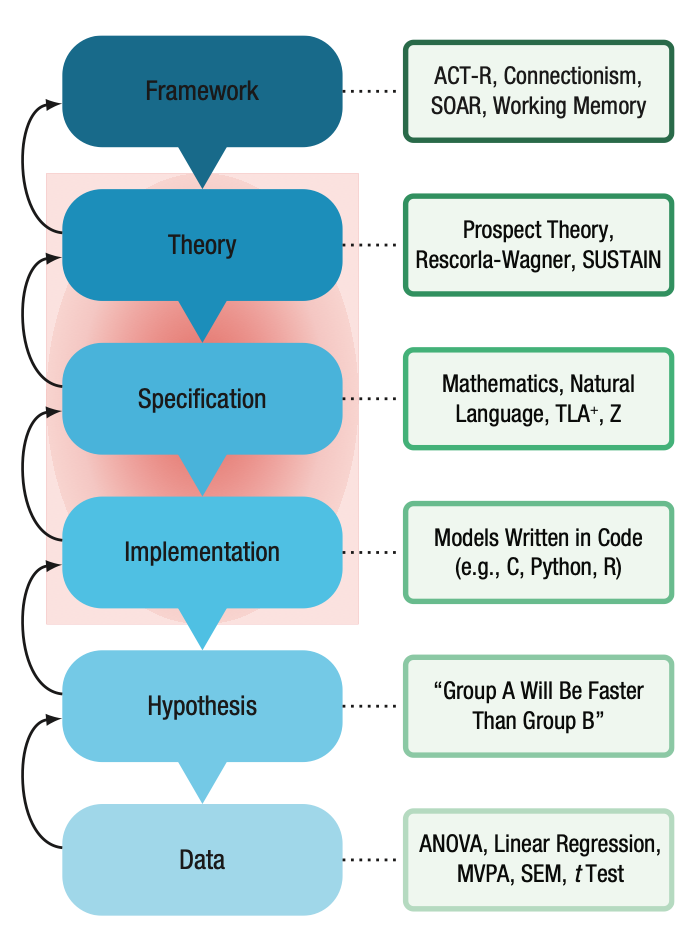

(Farrell & Lewandowsky, 2018; Guest & Martin, 2021; Yarkoni, 2022)

## What are the benefits of formal theories?

It forces researchers to be explicit about parts of the system under investigation and how they are linked together (e.g., $E = mc^2$).

[figure not shown]

(Hintzman, 1991)

## Formal theory from my lab

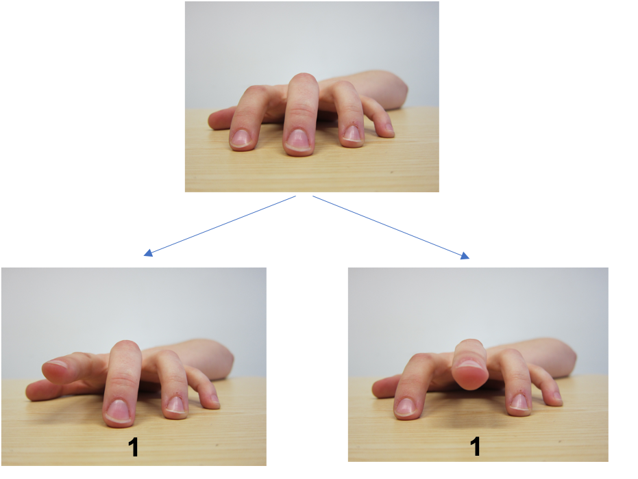

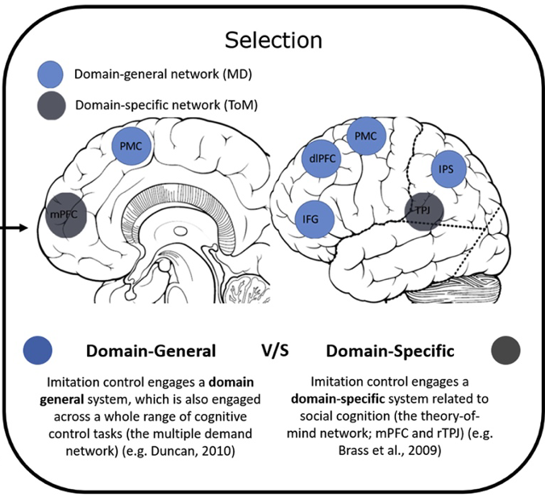

(Ward & Ramsey, 2024)

## Formal theory from my lab

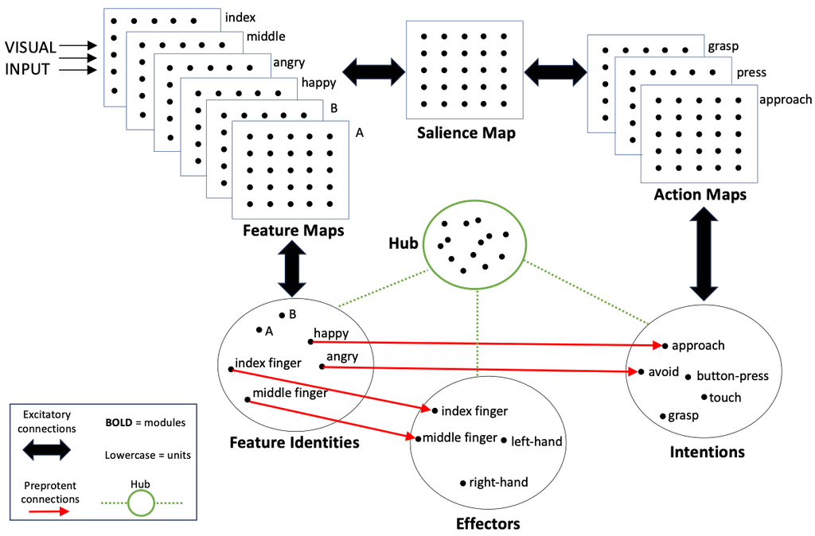

(Ward & Ramsey, 2024)

## Formal theory from my lab

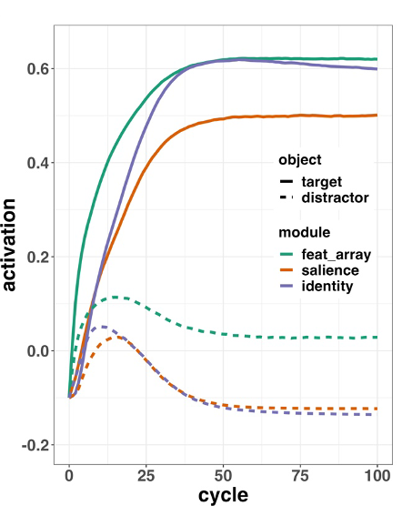

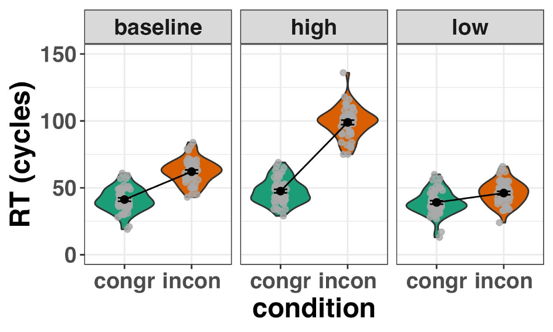

(Ward & Ramsey, 2024)

## Formal theory from my lab

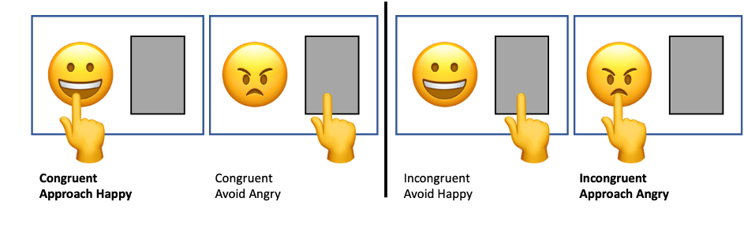

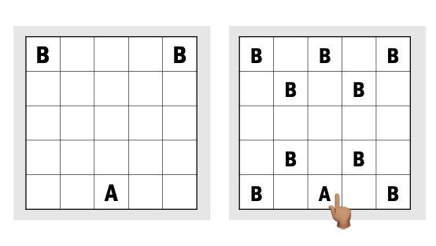

(Ward & Ramsey, 2024)

## Formal theory from my lab

- The benefit of formal theory here is not that our model is **“correct”**, but that it is explicit and it can therefore be more easily be falsified.
- Formal theory reduces verbal wriggle room

[figure not shown]